# Coursera Capstone Project Milestone Report

Data Science Capstone by Johns Hopkins University

[®γσ, Eng Lian Hu](http://englianhu.wordpress.com) 白戸則道®

2016-04-28

# 1. Introduction

- Section 1.1 Assignment
- Section 1.2 Preparing the environment

## 1.1 Assignment

**Instructions**

The goal of this project is just to display that you’ve gotten used to working with the data and that you are on track to create your prediction algorithm. Please submit a report on [R Pubs](http://rpubs.com/) that explains your exploratory analysis and your goals for the eventual app and algorithm. This document should be concise and explain only the major features of the data you have identified and briefly summarize your plans for creating the prediction algorithm and [Shiny app](http://shiny.rstudio.com/) in a way that would be understandable to a non-data scientist manager. You should make use of tables and plots to illustrate important summaries of the data set. The motivation for this project is to:

You can create an account on [RPubs.com](http://rpubs.com/), [ShinyApps.io](http://www.shinyapps.io) and [®StudioConnect.com](https://beta.rstudioconnect.com/) to publish your reports or shiny apps

1. Demonstrate that you’ve downloaded the data and have successfully loaded it in.
2. Create a basic report of summary statistics about the data sets.
3. Report any interesting findings that you amassed so far.
4. Get feedback on your plans for creating a prediction algorithm and Shiny app.

Review criteria:

1. Does the link lead to an HTML page describing the exploratory analysis of the training data set?
2. Has the data scientist done basic summaries of the three files? Word counts, line counts and basic data tables?
3. Has the data scientist made basic plots, such as histograms to illustrate features of the data?
4. Was the report written in a brief, concise style, in a way that a non-data scientist manager could appreciate?

## 1.2 Preparing the environment

Loading The Required Libraries and creating support functions.

```r
## Loading the package 'BBmisc'
if(suppressMessages(!require('BBmisc'))) install.packages('BBmisc')
suppressMessages(library('BBmisc'))

pkgs <- c('tufte', 'knitr', 'rmarkdown', 'lubridate', 'plyr', 'dplyr', 'magrittr', 'purrr', 'stringr', 'stringi', 'wordcloud', 'slam', 'tm', 'igraph', 'NLP', 'xtable', 'SnowballC', 'rpart', 'RWeka', 'RColorBrewer', 'rvest', 'parallel', 'doParallel', 'ggplot2', 'googleVis', 'htmltools', 'rCharts', 'janeaustenr', 'syuzhet', 'viridis')
suppressAll(lib(pkgs))

## load in case of BBmisc::lib() doesn't work
suppressAll(plyr::l_ply(pkgs, require, quietly = TRUE))
rm(pkgs)
```

Creating a Parallel computing Cluster and setting adjustment.

```r
## Load BBmisc package again since there has error during knit (while working fine if run chunk-by-chunk)
suppressMessages(library('BBmisc'))

## Creating a parallel computing Cluster and support functions.
## Preparing the parallel cluster using the cores
doParallel::registerDoParallel(cores = 16)
#'@ BiocParallel::register(MulticoreParam(workers=8))

## Preparing the parallel cluster using the cores
suppressAll(library('parallel'))
jobcluster <- makeCluster(detectCores())
invisible(clusterEvalQ(jobcluster, library('tm')))
invisible(clusterEvalQ(jobcluster, library('RWeka')))
options(mc.cores = 2)

## Set the googleVis options first to change the behaviour of plot.gvis, so that only the chart
##  component of the HTML file is written into the output file.
##
## Set option to below if you want to plot an independent webpage with graph
#'@ op <- options(gvis.plot.tag=NULL)
op <- options(gvis.plot.tag='chart')

## knitr configuration
# invalidate cache when the tufte version changes
suppressAll(library('knitr'))

opts_chunk$set(tidy = TRUE, fig.path = 'figure/', comment = NA, message = FALSE, fig.keep = 'high', fig.width = 10, fig.height = 6, fig.align = 'center', cache.extra = packageVersion('tufte'), echo = TRUE, progress = TRUE)

## Setting for rCharts
## http://ramnathv.github.io/posts/rcharts-nvd3/
options(warn = -1, htmltools.dir.version = FALSE,
        rcharts.mode = 'iframesrc', rcharts.cdn = TRUE,
        RCHART_WIDTH = 600, RCHART_HEIGHT = 400,
        RCHART_TEMPLATE = 'Rickshaw.html', RCHART_LIB = 'morris')
```

# 2. Data

- Section 2.1 Collecting Data
- Section 2.2 Processing Data
- Section 2.2.1 Read Data
- Section 2.2.2 Analyse Data
- Section 2.3 Plot Histogram

## 2.1 Collecting Data

The dataset is downloadable in zipped file via [here](https://d396qusza40orc.cloudfront.net/dsscapstone/dataset/Coursera-SwiftKey.zip).

```r
if (!file.exists("data/")) dir.create("data/")

lnk <- "https://d396qusza40orc.cloudfront.net/dsscapstone/dataset/Coursera-SwiftKey.zip"
destfile <- "Coursera-SwiftKey.zip"

if (!file.exists(paste0("data/", destfile))) {
    download.file(lnk, destfile = paste0("data/", destfile))
}

if (!file.exists(paste0("data/final"))) {
    ## Unzip the dataset
    #'@ unzip(paste0('data/', destfile), exdir = 'data/final/de_DE', list = TRUE)
    # Error in unzip(paste0('data/', destfile), exdir = 'data/final/de_DE', :
    # 'exdir' does not exist
    unzip(paste0("data/", destfile), exdir = "data/")
}

## list down the details of the zipped file
unzip(paste0("data/", destfile), list = TRUE)
```

```
                            Name    Length                Date
1                         final/         0 2014-07-22 10:10:00
2                   final/de_DE/         0 2014-07-22 10:10:00
3  final/de_DE/de_DE.twitter.txt  75578341 2014-07-22 10:11:00
4    final/de_DE/de_DE.blogs.txt  85459666 2014-07-22 10:11:00
5     final/de_DE/de_DE.news.txt  95591959 2014-07-22 10:11:00
6                   final/ru_RU/         0 2014-07-22 10:10:00
7    final/ru_RU/ru_RU.blogs.txt 116855835 2014-07-22 10:12:00
8     final/ru_RU/ru_RU.news.txt 118996424 2014-07-22 10:12:00
9  final/ru_RU/ru_RU.twitter.txt 105182346 2014-07-22 10:12:00
10                  final/en_US/         0 2014-07-22 10:10:00
11 final/en_US/en_US.twitter.txt 167105338 2014-07-22 10:12:00
12    final/en_US/en_US.news.txt 205811889 2014-07-22 10:13:00
13   final/en_US/en_US.blogs.txt 210160014 2014-07-22 10:13:00
14                  final/fi_FI/         0 2014-07-22 10:10:00
15    final/fi_FI/fi_FI.news.txt  94234350 2014-07-22 10:11:00
16   final/fi_FI/fi_FI.blogs.txt 108503595 2014-07-22 10:12:00
17 final/fi_FI/fi_FI.twitter.txt  25331142 2014-07-22 10:10:00
```

From above information, we can know the information of the zipped files, and now we try to list out the documents for this mile-stone report as well as the summary of files.

```r
## Load plyr and dplyr packages again since there has error during knit
## (while working fine if run chunk-by-chunk)
suppressAll(library("plyr"))
suppressAll(library("dplyr"))

## files for this mile-stone report
lsfiles <- list.files("data/final/de_DE")
lsfiles
```

```
[1] "de_DE.blogs.txt"   "de_DE.news.txt"    "de_DE.twitter.txt"
```

```r
## summary of files
datafiles <- paste0("data/final/de_DE/", lsfiles)
rm(lsfiles)
llply(as.list(datafiles), file.info) %>% rbind_all
```

```
Source: local data frame [3 x 10]

      size isdir  mode               mtime               ctime
     (dbl) (lgl) (int)              (time)              (time)
1 85459666 FALSE   420 2016-04-27 12:06:03 2016-04-27 12:06:03
2 95591959 FALSE   420 2016-04-27 12:06:04 2016-04-27 12:06:04
3 75578341 FALSE   420 2016-04-27 12:06:02 2016-04-27 12:06:02
Variables not shown: atime (time), uid (int), gid (int), uname (chr),
  grname (chr)
```

## 2.2 Processing Data

### 2.2.1 Read Data

Now we need to read the dataset prior to analyse. R is fairly slow in reading files. `read.table()` is slow, `scan()` a bit faster, and `readLines()` fastest. `stringi::stri_read_lines()` is a substitute of `readLines()`.

[stri_read_lines](http://docs.rexamine.com/R-man/stringi/stri_read_lines.html) is a substitute for the system’s `readLines` function, with the ability to auto-detect input encodings (or specify one manually), re-encode input without any strange function calls or sys options change, and split the text into lines with [`stri_split_lines1`](http://docs.rexamine.com/R-man/stringi/stri_split_lines.html) (which conforms with the Unicode guidelines for newline markers).

Sad, isn’t it? And what does R do? Process data. So we read large files in all the time. But beyond `readLines()`, R has deeper routines for reading files. There are also `readChar()` and `readBin()`. It turns out that using these, one can read in files faster. You can refer to **Faster files in R**[(http://www.r-bloggers.com/faster-files-in-r/)].

Faster files in R

```r
## Load plyr and stringr packages again since there has error during knit
## (while working fine if run chunk-by-chunk)
suppressAll(library("plyr"))
suppressAll(library("stringr"))

## Creating a parallel computing Cluster and support functions.  Preparing
## the parallel cluster using the cores
doParallel::registerDoParallel(cores = 16)

## http://www.r-bloggers.com/faster-files-in-r/ Run without parallel
## computing readLines in normal way
system.time(suppressAll(dat1 <- llply(datafiles, function(x) {
    readLines(x, encoding = "UTF-8")  #   user  system elapsed
})))  # 18.937   0.240  19.485
```

```
   user  system elapsed
 15.895   0.321  16.235
```

```r
## ReadLines in binary mode
system.time(suppressAll(dat2 <- llply(datafiles, function(x) {
    con <- file(x, open = "rb")
    result <- readLines(con, encoding = "UTF-8", file.info(x)$size)
    close(con)
    return(result)  #   user  system elapsed
})))  # 19.942   0.659  20.625
```

```
   user  system elapsed
 11.237   0.556  11.819
```

```r
## readChar
system.time(suppressAll(dat3 <- llply(datafiles, function(x) {
    con <- file(x, open = "rb")
    result <- readChar(con, file.info(x)$size, useBytes = TRUE)
    close(con)
    strsplit(result, "\n", fixed = T, useBytes = T)[[1]] %>% str_replace_all("\r",
        "")  #   user  system elapsed
})))  #  5.882   0.188   2.075
```

```
   user  system elapsed
  6.540   0.581   7.122
```

```r
## Run with parallel computing readLines in normal way with parallel
## computing
#'@ system.time(suppressAll(
#'@   dat1p <- llply(datafiles, function(x){
#'@     readLines(x, encoding = 'UTF-8')                                 #   user  system elapsed
#'@   }, .parallel=TRUE)))                                               # 18.750   0.105  18.877
```

```r
## ReadLines in binary mode with parallel computing
#'@ system.time(suppressAll(
#'@   dat2p <- llply(datafiles, function(x){
#'@     con <- file(x, open = 'rb')
#'@     result <- readLines(con, encoding = 'UTF-8', file.info(x)$size)
#'@     close(con)
#'@     return(result)                                                   #   user  system elapsed
#'@   }, .parallel=TRUE)))                                               # 20.348   0.720  21.095
```

```r
## readChar with parallel computing
#'@ system.time(suppressAll(
#'@   dat3p <- llply(datafiles, function(x){
#'@     con <- file(x, open = 'rb')
#'@     result <- readChar(con, file.info(x)$size, useBytes=TRUE)
#'@     close(con)
#'@     strsplit(result,'\n', fixed=T, useBytes=T)[[1]] %>%
#'@       str_replace_all('\r', '')                                      #   user  system elapsed
#'@ }, .parallel=TRUE)))                                                 #  5.858   0.158   2.019
```

```r
## readChar seperately in list
system.time(suppressAll({
    dat3s <- list(blogs = readChar(file(datafiles[1], "rb"), file.info(datafiles)$size[1],
        useBytes = TRUE) %>% strsplit("\n", fixed = T, useBytes = T) %>% unlist %>%
        str_replace_all("\r", ""), news = readChar(file(datafiles[2], "rb"),
        file.info(datafiles)$size[2], useBytes = TRUE) %>% strsplit("\n", fixed = T,
        useBytes = T) %>% unlist %>% str_replace_all("\r", ""), twitter = readChar(file(datafiles[3],
        "rb"), file.info(datafiles)$size[3], useBytes = TRUE) %>% strsplit("\n",
        fixed = T, useBytes = T) %>% unlist %>% str_replace_all("\r", "")) %>%
        llply(unlist)  #   user  system elapsed
}))  #  5.123   0.214   1.337
```

```
   user  system elapsed
  5.458   0.296   5.758
```

```r
#'@ names(dat1) <- names(dat1p) <- names(dat2) <- names(dat2p) <-
#'@   names(dat3) <- names(dat3p) <- c('blogs', 'news', 'twitter')
names(dat1) <- names(dat2) <- names(dat3) <- c("blogs", "news", "twitter")

## Delete the data folders to save the capacity.
unlink("data/final", recursive = TRUE)

#'@ dats <- c(dat1, dat1p, dat2, dat2p, dat3, dat3p, dat3s)
dats <- list(dat1, dat2, dat3, dat3s)

suppressAll(rm(dat1, dat1p, dat2, dat2p, dat3, dat3p, dat3s))
llply(dats, llply, class)
```

```
[[1]]
[[1]]$blogs
[1] "character"

[[1]]$news
[1] "character"

[[1]]$twitter
[1] "character"


[[2]]
[[2]]$blogs
[1] "character"

[[2]]$news
[1] "character"

[[2]]$twitter
[1] "character"


[[3]]
[[3]]$blogs
[1] "character"

[[3]]$news
[1] "character"

[[3]]$twitter
[1] "character"


[[4]]
[[4]]$blogs
[1] "character"

[[4]]$news
[1] "character"

[[4]]$twitter
[1] "character"
```

```r
str(dats)
```

```
List of 4
 $ :List of 3
  ..$ blogs  : chr [1:371440] "Irgendwann wird es Zeit. Ich schleppe es ja auch jeden Tag mit mir herum. Da leidet es schon ein wenig. Nicht nur die Tasten ge"| __truncated__ "Kommentar: auch hier wird durch die Voranstellung einer entsprechenden Bemuskelung des Halses vor die Eleganz die Sportlichk…
  ..$ news   : chr [1:244743] "Das Rezept für ihre Schokobrezln hat die 60-Jährige schon vor 26 Jahren in einer österreichischen Sendung entdeckt. Mittlerweil"| __truncated__ "Für die Linksparteibewerber ist nun die entscheidende Frage, wie sich SPD- und Grünenwähler in einer solchen Persönlichkeits…
  ..$ twitter: chr [1:947774] "irgendwas stimmt mut meinem internet am pc nich :(" "\"Wir haben hier ein angebrochenes Fass Bier!\" habe ich mir auch anders vorgestellt. Fragt sich nur, wer darüber gekotzt hat." "Meine Kommilitonen beschweren sich, nie Freizeit zu haben... Anscheinend mache ich was …
 $ :List of 3
  ..$ blogs  : chr [1:371440] "Irgendwann wird es Zeit. Ich schleppe es ja auch jeden Tag mit mir herum. Da leidet es schon ein wenig. Nicht nur die Tasten ge"| __truncated__ "Kommentar: auch hier wird durch die Voranstellung einer entsprechenden Bemuskelung des Halses vor die Eleganz die Sportlichk…
  ..$ news   : chr [1:244743] "Das Rezept für ihre Schokobrezln hat die 60-Jährige schon vor 26 Jahren in einer österreichischen Sendung entdeckt. Mittlerweil"| __truncated__ "Für die Linksparteibewerber ist nun die entscheidende Frage, wie sich SPD- und Grünenwähler in einer solchen Persönlichkeits…
  ..$ twitter: chr [1:947774] "irgendwas stimmt mut meinem internet am pc nich :(" "\"Wir haben hier ein angebrochenes Fass Bier!\" habe ich mir auch anders vorgestellt. Fragt sich nur, wer darüber gekotzt hat." "Meine Kommilitonen beschweren sich, nie Freizeit zu haben... Anscheinend mache ich was …
 $ :List of 3
  ..$ blogs  : chr [1:371440] "Irgendwann wird es Zeit. Ich schleppe es ja auch jeden Tag mit mir herum. Da leidet es schon ein wenig. Nicht nur die Tasten ge"| __truncated__ "Kommentar: auch hier wird durch die Voranstellung einer entsprechenden Bemuskelung des Halses vor die Eleganz die Sportlichk…
  ..$ news   : chr [1:244743] "Das Rezept für ihre Schokobrezln hat die 60-Jährige schon vor 26 Jahren in einer österreichischen Sendung entdeckt. Mittlerweil"| __truncated__ "Für die Linksparteibewerber ist nun die entscheidende Frage, wie sich SPD- und Grünenwähler in einer solchen Persönlichkeits…
  ..$ twitter: chr [1:8653] "irgendwas stimmt mut meinem internet am pc nich :(" "\"Wir haben hier ein angebrochenes Fass Bier!\" habe ich mir auch anders vorgestellt. Fragt sich nur, wer darüber gekotzt hat." "Meine Kommilitonen beschweren sich, nie Freizeit zu haben... Anscheinend mache ich was fa…
 $ :List of 3
  ..$ blogs  : chr [1:371440] "Irgendwann wird es Zeit. Ich schleppe es ja auch jeden Tag mit mir herum. Da leidet es schon ein wenig. Nicht nur die Tasten ge"| __truncated__ "Kommentar: auch hier wird durch die Voranstellung einer entsprechenden Bemuskelung des Halses vor die Eleganz die Sportlichk…
  ..$ news   : chr [1:244743] "Das Rezept für ihre Schokobrezln hat die 60-Jährige schon vor 26 Jahren in einer österreichischen Sendung entdeckt. Mittlerweil"| __truncated__ "Für die Linksparteibewerber ist nun die entscheidende Frage, wie sich SPD- und Grünenwähler in einer solchen Persönlichkeits…
  ..$ twitter: chr [1:8653] "irgendwas stimmt mut meinem internet am pc nich :(" "\"Wir haben hier ein angebrochenes Fass Bier!\" habe ich mir auch anders vorgestellt. Fragt sich nur, wer darüber gekotzt hat." "Meine Kommilitonen beschweren sich, nie Freizeit zu haben... Anscheinend mache ich was fa…
```

```r
## randomly take one data as sample files for further analysis
smp <- sample(dats, size = 1) %>% unlist(recursive = FALSE)
```

`readChar()` will get the words but end with character `\r` in every single line. Secondly it will be in class `list` and you just need to `unlist`. There has another thing need to be considered which are split the string and need to replace the characters `\n` and `\r` via `strsplit(result,'\n', fixed=T, useBytes=T)[[1]] %>% str_replace_all('\r', '')` as mentioned in description of function [`stri_stats_general()`](http://rpackages.ianhowson.com/rforge/stringi/man/stri_stats_general.html)

### 2.2.2 Analyse Data

Now we try to summarise the files as below.

```r
## Load stringi package again since there has error during knit (while
## working fine if run chunk-by-chunk)
suppressAll(library("stringi"))
data.frame(File = names(smp), t(sapply(smp, stri_stats_general))) %>% tbl_df %>%
    kable
```

| File | Lines | LinesNEmpty | Chars | CharsNWhite |
| --- | --- | --- | --- | --- |
| blogs | 371440 | 371440 | 83204141 | 70922562 |
| news | 244743 | 244743 | 93388797 | 80414253 |
| twitter | 947774 | 947774 | 72776632 | 61920929 |

*table 2.2.2.1 : Summary of text files*

```r
cWords <- llply(smp, stri_count_words)
ldply(cWords, summary) %>% kable  #'@ llply(cWords, summary) #if you want to display in list
```

| .id | Min. | 1st Qu. | Median | Mean | 3rd Qu. | Max. |
| --- | --- | --- | --- | --- | --- | --- |
| blogs | 0 | 8 | 22 | 34.14 | 47 | 1638 |
| news | 1 | 33 | 51 | 54.65 | 72 | 603 |
| twitter | 0 | 7 | 12 | 12.29 | 17 | 42 |

*table 2.2.2.2 : Quantiles of text files*

## 2.3 Plot Histogram

We try to make the maximum of the lines inside text files equivalence in order to plot a histogram with `rCharts`.

[`rCharts` packages](http://rcharts.io/gallery/)

```r
mxSub <- llply(cWords, function(x) max(length(x)))
mxAll <- mxSub %>% unlist %>% max
chSub <- llply(mxSub, function(x) mxAll - x)
cWords1 <- llply(seq(cWords), function(i) {
    c(cWords[[i]], rep(0, chSub[[i]]))
}) %>% data.frame(Line = seq(mxAll), .) %>% tbl_df

names(cWords1) <- c("Line", names(cWords))
rm(mxSub, mxAll, chSub)
```

Here I plot an histogram via `gvisHistogram()`.

Where you can refer to [Annotation charts and histograms with googleVis](http://www.r-bloggers.com/annotation-charts-and-histograms-with-googlevis/) inside [**googleVis** packages](https://github.com/mages/googleVis)

The 10000 sample data will be taken as obeservation from the populations to plot the histogram chart since the population size is very large *947774 x 4* and costing time.

```r
## Load googleVis package again since there has error during knit (while
## working fine if run chunk-by-chunk)
suppressAll(library("googleVis"))

## Set the googleVis options first to change the behaviour of plot.gvis, so
## that only the chart component of the HTML file is written into the output
## file.
op <- options(gvis.plot.tag = "chart")

## Set option to below if you want to plot an independent webpage with graph
#'@ op <- options(gvis.plot.tag=NULL)

# Number of bins chosen automatically, which is sometimes bad
gvis.options <- list(legend = "{ position: 'top', maxLines: 2 }", colors = "['#5C3292', '#1A8763', '#871B47']",
    hAxis = "{title:'names(cWords1)'}", width = 600, height = 400)
hist.gvis <- gvisHistogram(data = cWords1[sample(nrow(cWords1), 10000), names(cWords)],
    option = gvis.options, chartid = "Histogram")
#'@ print(hist.gvis, tag='chart')
plot(hist.gvis)
```

[output not shown]

[output cut: 50034 more lines]

[output not shown]

```r
#'@ hist.gvis
```

# 3. Data Mining

- Section 3.1 Sampling the Data
- Section 3.2 Text Mining
  - Section 3.2.1 Cleaning Data
  - Section 3.2.2 Word Frequency
  - Section 3.2.3 Relationships Between Terms
- Section 3.3 Plot Histogram

## 3.1 Sampling the Data

My previous version report united the sampling but now I sampling seperately in order to make a better interactable data visulization via [MultiBarChart with NVD3](http://rcharts.io/viewer/?5457195#.VxpRHfl96Ul)/[rCharts: Highcharts example](http://rstudio-pubs-static.s3.amazonaws.com/5548_c3b680696b084e5db17eecf8c079a3c1.html).

Coding inside section **Subsetting the dataset** on [Coursera Capstone Project Milestone Report](http://rstudio-pubs-static.s3.amazonaws.com/66352_a419309e18bc49e79aa1b8de27c9dad5.html#subsetting-the-dataset)

The 3000 sample data will be taken as obeservation from the populations.

```r
## Load tm package again since there has error during knit (while working
## fine if run chunk-by-chunk)
suppressAll(library("tm"))

## Randomly sampling the dataset 5000 data sample taken from populations
#'@ dataSubset <- sample(unlist(smp), size = 3000, replace = TRUE) #united 3 files into one
dataSubset <- llply(smp, sample, size = 3000)  #, replace = TRUE) #seperately for rCharts
corpus <- llply(dataSubset, function(x) Corpus(VectorSource(x)))
rm(dataSubset)
```

## 3.2 Text Mining

### 3.2.1 Cleaning Data

We need to filter and clean the data for exploratory analysis.

```r
## Load rvest package again since there has error during knit (while working
## fine if run chunk-by-chunk)
#'@ suppressAll(library('rvest'))

## bad words in german language
#'@ lnk <- 'http://www.youswear.com/?language=German'
#'@ bWords <- lnk %>% html_session %>% html_nodes('div a') %>%
#'@   html_text(trim=TRUE) %>% .[nchar(iconv(., 'ISO-8859-1', 'UTF-8')) > 0] %>%
#'@   str_replace_all('�', '') %>% stri_trans_tolower
```

Due to there has unconvertable word which is `lnk %>% html_session %>% html_nodes('div a') %>% html_text(trim=TRUE) %>% .[735]`(`V\xf5ro` or `V�ro`) while you can use `nchar(iconv(bWords, 'ISO-8859-1', 'UTF-8'))` to solve it.

You can refer to [How to calculate nchar in R?](http://stackoverflow.com/questions/13328838/how-to-calculate-nchar-in-r) and [R: invalid multibyte string](http://stackoverflow.com/questions/4993837/r-invalid-multibyte-string) which provides the answer about how to skip the untranslatable words. [Working with text data: transforming and searching](https://www3.nd.edu/~steve/computing_with_data/19_strings_and_text/strings_and_text.html#/) is another good presentation file for string management

Tasks such as removing punctuations, white spaces and numbers as well as converting text to lowercase are performed. Removal of profanity also been performed and sourced the list of words from [here](http://www.youswear.com/?language=German).

Since I changed from united data to a list of data for text mining. Here I try to make it simpler to apply multiple corpuras to a list of data.

I tried to refer to [Make dataframe of top N frequent terms for multiple corpora using tm package in R](http://stackoverflow.com/questions/15506118/make-dataframe-of-top-n-frequent-terms-for-multiple-corpora-using-tm-package-in) and [More efficient means of creating a corpus and DTM](http://stackoverflow.com/questions/25330753/more-efficient-means-of-creating-a-corpus-and-dtm) but `tm_map(corpus, removeNumbers)` doesn’t work, here I skip to filter swear words

```r
## Cleaning the data (process the text) for Exploratory Analysis
skipWords1 <- function(x) removeWords(x, stopwords("german"))
#'@ skipWords2 <- function(x) removeWords(x, bWords)

funcs <- list(content_transformer(tolower), removePunctuation, stemDocument,
    stripWhitespace, removeNumbers, PlainTextDocument, skipWords1)  #, skipWords2)
corpus <- llply(corpus, function(x) {
    cp <- tm_map(x, FUN = tm_reduce, tmFuns = funcs)
    #'@ tm_map(cp, removeWords, bWords)
    # Error in UseMethod('meta', x) : no applicable method for 'meta' applied to
    # an object of class 'try-error'
})  #'@ , mc.cores=2)) #apply mc.cores=2 will be slower

rm(lnk, bWords, skipWords1, skipWords2, funcs)
```

### 3.2.2 Word Frequency

Well, now we try to manipulate **Term Document Matrix** file and you can refer to **Text Mining in R**. Here is an example that you can refer to [Basic Text Mining in R](https://rstudio-pubs-static.s3.amazonaws.com/31867_8236987cf0a8444e962ccd2aec46d9c3.html).

This vignette — [**Introduction to the tm Package** - Text Mining in R](https://cran.r-project.org/web/packages/tm/vignettes/tm.pdf) gives a short introduction to text mining in R utilizing the text mining framework provided by the [**tm** package](https://cran.r-project.org/web/packages/tm/index.html) which present methods for data import, corpus handling, preprocessing, metadata management, and creation of term-document matrices. The author focus is on the main aspects of getting started with text mining in R — an in-depth description of the text mining infrastructure offered by tm was published in the Journal of Statistical Software (Feinerer et al., 2008). An introductory article on text mining in R was published in R News (Feinerer, 2008).

`row_sums()` has not inside `tm` package now and you need to load from slam.

`slam::row_sums` is designate for *simple_triplet_matrix* which different with `rowSums` while you can refer to [Row sum for large term-document matrix / simple_triplet_matrix ?? {tm package}](http://stackoverflow.com/questions/21921422/row-sum-for-large-term-document-matrix-simple-triplet-matrix-tm-package) and [Can’t find documentation for R function row_sums and col_sums](http://stackoverflow.com/questions/15055584/cant-find-documentation-for-r-function-row-sums-and-col-sums)

```r
## Convert to a document term matrix format data
#'@ tdm <- llply(corpus, function(x) {
#'@   dT = TermDocumentMatrix(x)
#'@   dT$tot = row_sums(dT, na.rm = TRUE) #slam::row_sums() or slam::rollup()
#'@   return(dT)})

dtm <- llply(corpus, function(x) {
    DocumentTermMatrix(x)
})

dtmFreq <- llply(dtm, function(x) colSums(as.matrix(x)))
dtmData <- llply(dtmFreq, function(x) data.frame(Term = names(x), Freq = x) %>%
    tbl_df %>% arrange(desc(Freq)))

## Only top 1000 rows / 10% from the sample data be display.  filter top 1000
## rows will appear
#'@ dtmData <- llply(dtmData, function(x) x[seq(1000),])
#'@ dtmData <- ldply(dtmData, function(x) x[seq(1000),]) %>% tbl_df %>% rename(Group=.id, Term=Term, Freq=Freq)

## Only duplicated Term == 3 times will plot a better graph compare to
## ramdomly picked.
dtmData <- ldply(dtmData) %>% tbl_df %>% filter(duplicated(Term) | duplicated(Term,
    fromLast = TRUE)) %>% rename(Group = .id, Term = Term, Freq = Freq)

dup3 <- dtmData %>% ddply(.(Term, Freq), nrow) %>% tbl_df %>% arrange(Term) %>%
    filter(V1 == 3)
dup3 <- dup3$Term
dtmCharts <- dtmData %>% filter(Term %in% dup3) %>% arrange(Term)
```

```r
llply(dtm, findFreqTerms, lowfreq = 300)
```

```
$blogs
[1] "dass" "die"  "ich"

$news
[1] "das"  "dass" "der"  "die"  "euro" "jahr" "mehr" "sagt"

$twitter
character(0)
```

## 3.2.3 Relationships Between Terms

**Term Correlations**

If you have a term in mind that you have found to be particularly meaningful to your analysis, then you may find it helpful to identify the words that most highly correlate with that term. If words always appear together, then correlation=1.0.

```r
#'@ llply(dtm, findAssocs, c('das', 'die'), corlimit=0.98) # specifying a correlation limit of 0.98
## Randomly pick a dataset to inspect
findAssocs(dtm[[sample(names(dtm), size = 1)]], c("das", "die"), corlimit = 0.98)
```

```
$das
numeric(0)

$die
numeric(0)
```

Now we try to look inside the cross table matrix over the data.

```r
## Randomly pick a dataset to inspect
inspect(dtm[[sample(names(dtm), size = 1)]][1000:1005, 1000:1005])
```

```
<<DocumentTermMatrix (documents: 6, terms: 6)>>
Non-/sparse entries: 0/36
Sparsity           : 100%
Maximal term length: 13
Weighting          : term frequency (tf)

              Terms
Docs           bodenkontakt bodense bodenständig boersenverein bogen boh
  character(0)            0       0            0             0     0   0
  character(0)            0       0            0             0     0   0
  character(0)            0       0            0             0     0   0
  character(0)            0       0            0             0     0   0
  character(0)            0       0            0             0     0   0
  character(0)            0       0            0             0     0   0
```

## 3.3 Plot Histogram

```r
## Load rCharts package again since there has error during knit (while
## working fine if run chunk-by-chunk)
suppressAll(library("rCharts"))

n1 <- nPlot(Freq ~ Group + Term, group = "Group", data = dtmCharts, type = "multiBarChart")
## If you want to stack the bars by default, add the line `n1$chart(stacked =
## TRUE)` before you print the chart.
#'@ n1$chart(stacked = TRUE)
#'@ n1$show('inline', include_assets = TRUE, cdn = FALSE)
#'@ n1$print('iframesrc', cdn =TRUE, include_assets=TRUE)
n1$print("inline", include_assets = TRUE, cdn = FALSE)
```

[output not shown]

[output cut: 2860 more lines]

[output not shown]

```r
#'@ n1$save('n1.html', cdn = TRUE); n1$publish('n1',host='gist')
```

# 4. Data Visulaization

- Section 4.1 Plot Word Cloud
- Section 4.2 Plot Sentimental Graph
- Section [4.3 RWeka]
  - Section 4.3.1 Prediction with J48 (aka C4.5)
  - Section 4.3.2 Evaluation in Weka
- Section 4.4 Plot Dicision Tree

## 4.1 Plot Word Cloud

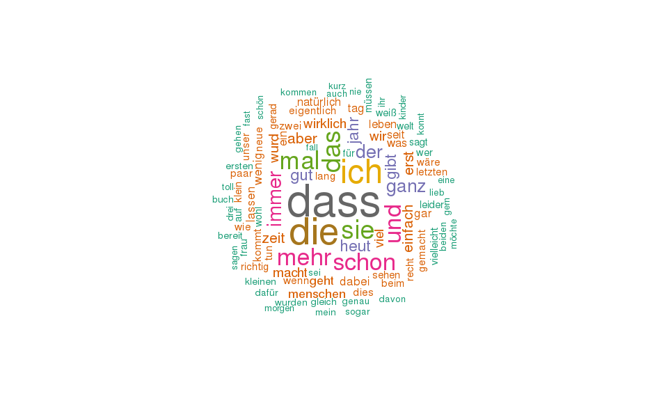

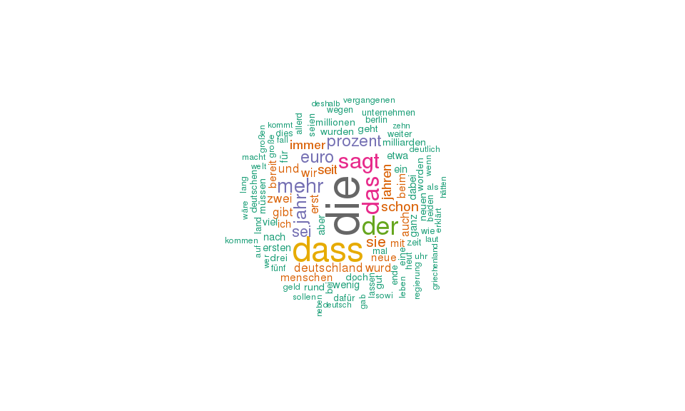

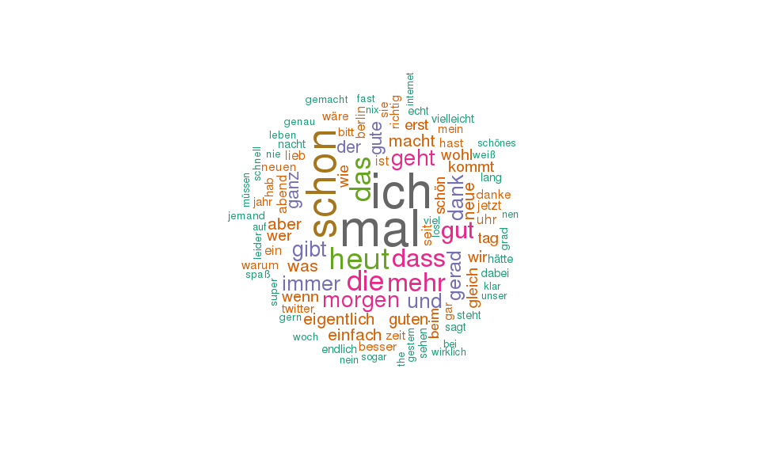

```r
## Load wordcloud package again since there has error during knit (while
## working fine if run chunk-by-chunk)
suppressAll(library("wordcloud"))

## setting of display of the graphs 3 figures arranged in 3 rows and 1 column
#'@ par(mfrow=c(3,1))

## word cloud funcs
wordPlot <- function(corpusData) {
    suppressAll(llply(corpusData, function(x) {
        wordcloud(words = x, random.order = FALSE, rot.per = 0.35, use.r.layout = FALSE,
            max.words = 100, colors = brewer.pal(8, "Dark2"))
        #'@ text(x = 0.5, y = 1.1, 'TriGram Word Cloud')
    }))
}

## Plot wordcloud graph
wordPlot(corpus)
```

*graph 4.1.1 : Wordcloud graphs.*

## 4.2 Plot Sentimental Graph

You might think literary criticism is no place for statistical analysis, but given digital versions of the text you can, for example, use sentiment analysis to the dataset. [Pride and Prejudice and Z-scores](http://blog.revolutionanalytics.com/2016/04/pride-and-prejudice-and-z-scores.html) introduced a R package termed as [`janeaustenr` packages](https://github.com/juliasilge/janeaustenr) and [Introduction to the `Syuzhet` Package](https://cran.r-project.org/web/packages/syuzhet/vignettes/syuzhet-vignette.html).

The author make an R package for her texts, for easy access for herself and anybody else who would like to do some text analysis on a nice sample of prose where you can read through [If I Loved Natural Language Processing Less, I Might Be Able to Talk About It More](http://juliasilge.com/blog/If-I-Loved-NLP-Less/) for more details.

[figure not shown]

[figure not shown]

[figure not shown]

```r
## Load ggplot2 package again since there has error during knit (while working fine if run chunk-by-chunk)
suppressAll(library('ggplot2'))

## plot sentiment graph
## http://juliasilge.com/blog/If-I-Loved-NLP-Less/
plot_sentiment <- function (mySentiment, myAnnotate){
  g = ggplot(data = mySentiment, aes(x = linenumber, y = sentiment)) +
    geom_bar(stat = "identity", color = "midnightblue") +
    geom_label(data = myAnnotate, aes(x, y, label=label), hjust = 0.5,
               label.size = 0, size = 3, color="#2b2b2b", inherit.aes = FALSE) +
    geom_segment(data = myAnnotate, aes(x = x, y = y1, xend = x, yend = y2),
                 arrow = arrow(length = unit(0.04, "npc")), inherit.aes = FALSE) +
    theme_minimal() + labs(y = "Sentiment",
                           caption = "Text sourced from Project Gutenberg") +
    scale_x_discrete(expand=c(0.02,0)) +
    theme(plot.caption=element_text(size=8)) +
    theme(axis.text.y=element_text(margin=margin(r=-10))) +
    theme(axis.title.x=element_blank()) +
    theme(axis.ticks.x=element_blank()) +
    theme(axis.text.x=element_blank())
  }

sent <- llply(split(dtmData, dtmData$Group), function(x){
  x %>% arrange(Group, Term) %>% mutate(linenumber=rownames(.), sentiment=Freq)
  })

marks <- llply(sent, function(df){
  set.seed(sample(100, size=1))
  data.frame(x=sample(df$linenumber, size=6),
             y=rep(max(df$Freq), 6), #y=height of labels
             label=sample(df$Term, size=6),
             y1=rep(ceiling(max(df$Freq)*0.95), 6), #y1=height of upper arrow
             y2=sample(ceiling(df$Freq*1.1), size=6)) #y2=height of lower arrow
  })

## setting of display of the graphs
## 3 figures arranged in 3 rows and 1 column
par(mfrow=c(3,1))

pp <- llply(seq(sent), function(i) {
  plot_sentiment(sent[[i]], marks[[i]]) +
    labs(title = expression(paste('Sentiment in ', italic('Northanger Abbey'))))})
names(pp) <- names(sent)
pp
```

*graph 4.2.1 : Sentimental graph of the files.*

## 4.3 RWeka

Weka has a GUI and can be directed via the command line with Java as well, and Weka has a large variety of algorithms included. If, for whatever reason, you do not find the algorithm you need being implemented in R, Weka might be the place to go. And the RWeka-package marries R and Weka. You are feel free to refer to [R talks to Weka about Data Mining](http://www.r-bloggers.com/r-talks-to-weka-about-data-mining/)

R provides us with excellent resources to mine data, and there are some good overviews out there:

- [Yanchang’s website](http://www.rdatamining.com/) with Examples and a nice [reference card](http://www.rdatamining.com/docs/R-refcard-data-mining.pdf)
- The rattle-package that introduces a [nice GUI for R](http://rattle.togaware.com/), and [Graham William’s compendium of tools](http://onepager.togaware.com/)
- The caret-package that offers a unified interface to running a multitude of model builders.

And there are other tools out there for data mining, like [Weka](http://www.cs.waikato.ac.nz/ml/weka/).

### 4.3.1 Prediction with J48 (aka C4.5)

We now build the classifier, and this works with the J48(.)-function:

```
#'@ dtm_j48 <- J48(Term~., data=dtmData[-1])
#Error in .jcall(o, "Ljava/lang/Class;", "getClass") :
#  java.lang.OutOfMemoryError: Java heap space
## subset some sample data in order to avoid memory space error
dtm_j48 <- J48(Term~., data=dtmData[1:100,-1])
dtm_j48
```

```
summary(dtm_j48)
```

```
plot(iris_j48)
```

### 4.3.2 Evaluation in Weka

```
eval_j48 <- evaluate_Weka_classifier(iris_j48, numFolds = 10, complexity = FALSE, seed = 1, class = TRUE)
eval_j48
```

## 4.4 Plot Dicision Tree

The [`rpart`](https://cran.r-project.org/web/packages/rpart/rpart.pdf) programs build classification or regression models of a very general structure using a two stage procedure; the resulting models can be represented as binary trees.

You can refer to few explanations documents and also examples via [Classification Trees using the rpart function](http://www.r-bloggers.com/classification-trees-using-the-rpart-function/), [An Introduction to Recursive Partitioning - Using the RPART Routines](https://cran.r-project.org/web/packages/rpart/vignettes/longintro.pdf) and [Tree-Based Models](http://www.statmethods.net/advstats/cart.html)

```
## Grow tree
fit <- rpart(Term ~ .id + Freq, method='class', data=dtmData)
summary(fit)
```

```
## Create attractive postscript plot of tree
post(fit, file = 'data/tree.ps', title = 'Classification Tree for Files')
```

# 5. NGrams Combine Words

- Section 5.1 Explore Data
- Section 5.2 Shiny App

## 5.1 Explore Data

Now that we have a cleansed data, it’s time to tokenize the words. We would identify appropriate tokens such as words, punctuation, and numbers. Then we structure the words for auto suggestion.

As suggested in the course content, writing a function for N-Grams that takes size and returns structured data set.

```r
## nGrams function
suppressAll(library("RWeka"))

nGramFn <- function(corpusData, ng) {
    options(mc.cores = 1)
    nGramTokenizer <- function(nData) NGramTokenizer(nData, Weka_control(min = ng,
        max = ng, delimiters = " \\r\\n\\t.,;:\"()?!"))
    tdMatrix <- DocumentTermMatrix(corpusData, control = list(tokenize = nGramTokenizer,
        removePunctuation = TRUE, stopwords = TRUE))
    tdMatrix <- as.data.frame(apply(tdMatrix, 1, sum))
    summary(tdMatrix)
    # colnames(tdMatrix) <- c('Frequency')
    return(tdMatrix)
}
```

Creating a function for plotting graph. This would sort the data and extra only top 10 words to be shown on the graph.

```r
## Filter Dataframe
filterData <- function(nDataFrame) {
    nDataFrame <- as.data.frame(cbind(rownames(nDataFrame), nDataFrame[, 1]))
    colnames(nDataFrame) <- c("Word", "Frequency")
    nDataFrame <- nDataFrame[order(nDataFrame$Frequency, decreasing = TRUE),
        ]
    print(head(nDataFrame))
    nDataFrame <- nDataFrame[1:10, ]
    return(nDataFrame)
}

## Crating nGrams graph
plotGraph <- function(nDataFrame, gName) {
    ggPlotData <- ggplot(nDataFrame, aes(x = Word, y = Frequency)) + geom_bar(stat = "Identity") +
        theme(axis.text.x = element_text(angle = 45, hjust = 1)) + ggtitle(paste("Graph for",
        gName))
    ggPlotData
}
```

```r
## Taking smaller sample again due to system always palsy
corpusData = llply(corpus, sample, size = 100)

nGram1 <- llply(corpusData, function(x) {
    nGramFn(x, ng = 1)
})
```

```r
nGram2 <- llply(corpusData, function(x) {
    nGramFn(x, ng = 2)
})
```

```r
nGram3 <- llply(corpusData, function(x) {
    nGramFn(x, ng = 3)
})
```

**Remarks** : Just wonder why the output of below coding doesn’t work, kindly refer to nGram.

I tried to knit on this particular section on [nGram Output](http://rpubs.com/englianhu/ngram-output) since it is works

```r
nG1 <- llply(nGram1, function(x) {
    filterData(x)
})
```

```
   Word Frequency
24   24        94
90   90         9
1     1         8
40   40         8
94   94         8
17   17         7
   Word Frequency
42   42        83
61   61        75
59   59        71
76   76         7
68   68        66
81   81        66
   Word Frequency
5     5         9
24   24         9
62   62         9
72   72         9
80   80         9
81   81         9
```

```r
nG2 <- llply(nGram2, function(x) {
    filterData(x)
})
```

```
   Word Frequency
24   24        94
1     1         9
9     9         9
21   21         9
82   82         9
94   94         9
   Word Frequency
34   34         9
89   89         9
42   42        84
61   61        76
59   59        70
68   68        68
   Word Frequency
5     5         9
9     9         9
14   14         9
38   38         9
51   51         9
62   62         9
```

```r
nG3 <- llply(nGram3, function(x) {
    filterData(x)
})
```

```
   Word Frequency
24   24        93
6     6         9
67   67         9
91   91         9
99   99         9
1     1         8
   Word Frequency
4     4         9
42   42        83
34   34         8
89   89         8
61   61        75
59   59        69
   Word Frequency
3     3         9
12   12         9
36   36         9
68   68         9
79   79         9
83   83         9
```

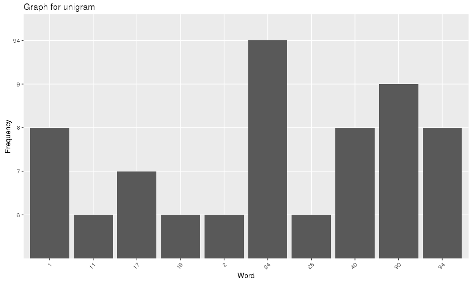

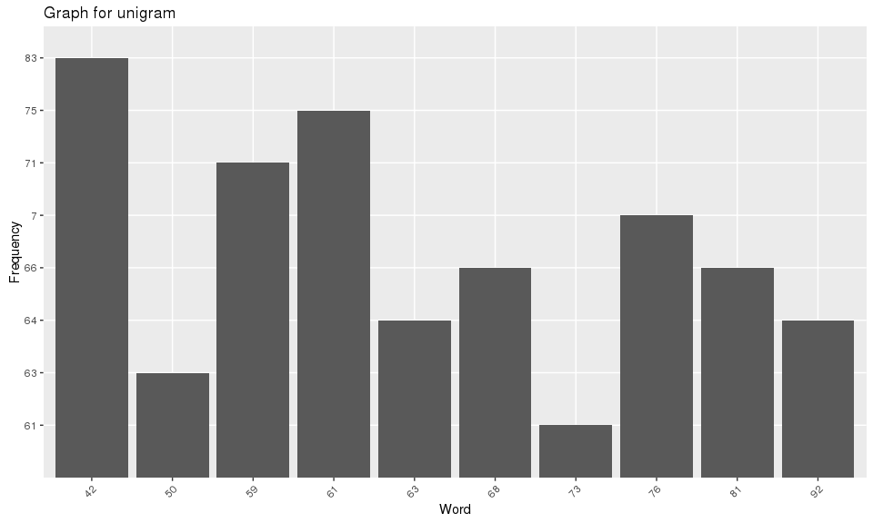

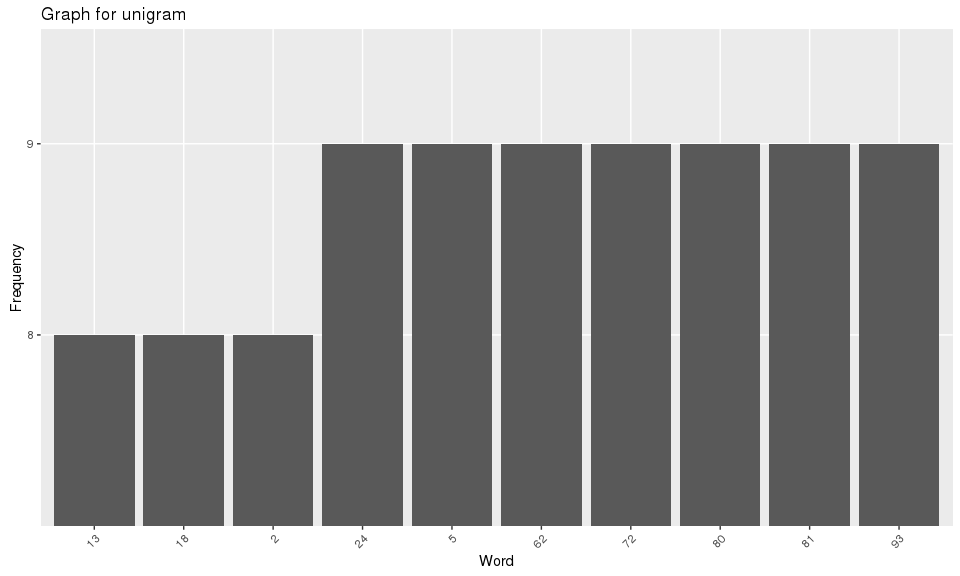

```r
llply(nG1, function(x) plotGraph(x, "unigram"))
```

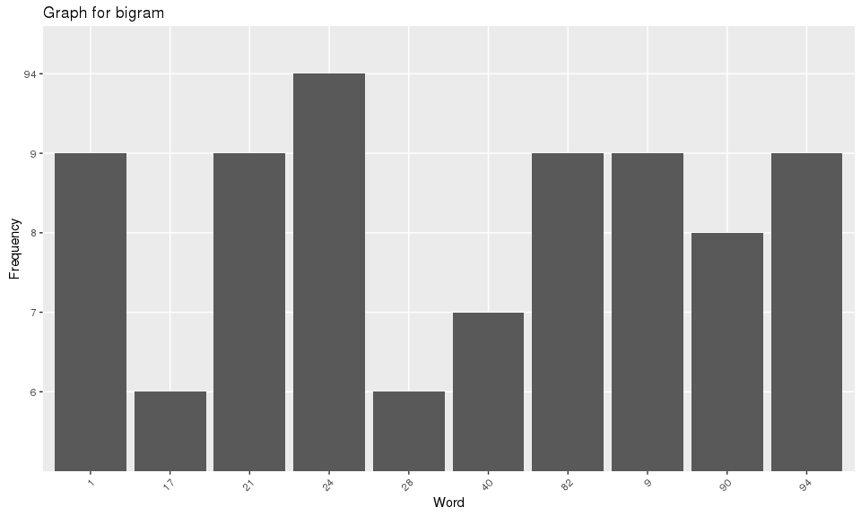

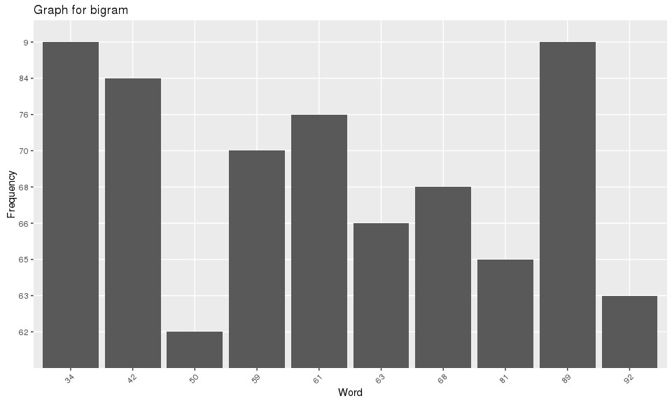

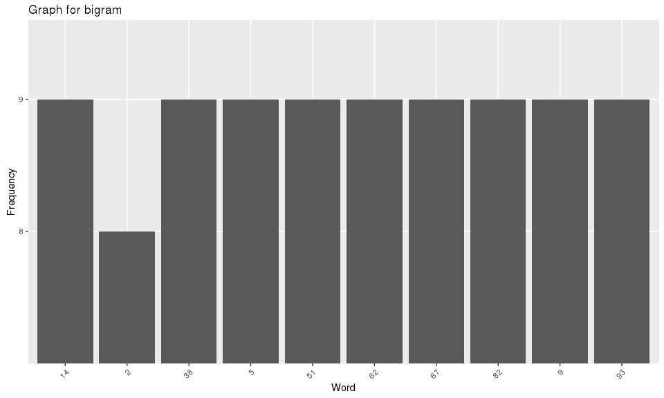

```r
llply(nG2, function(x) plotGraph(x, "bigram"))
```

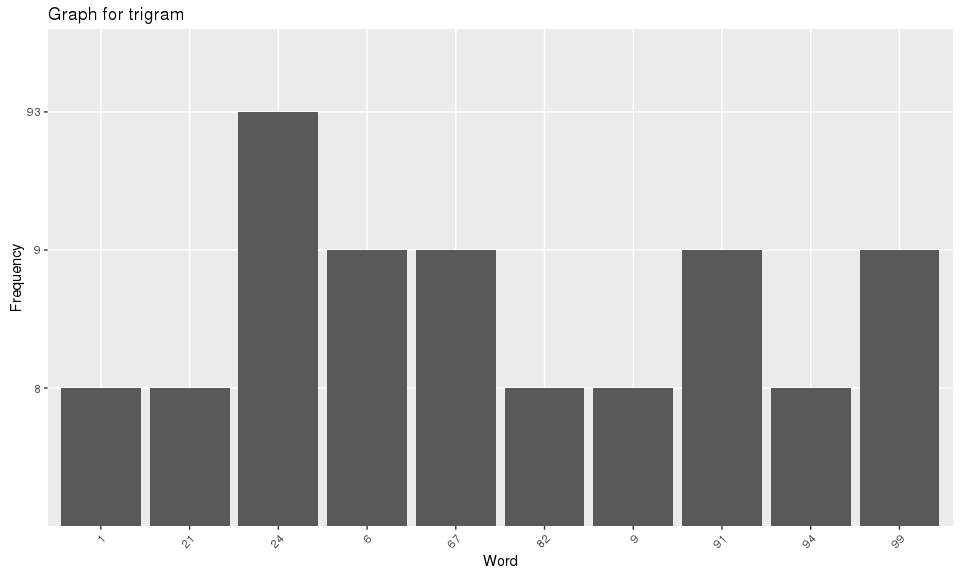

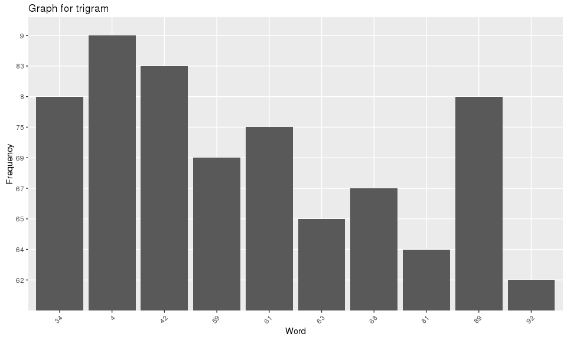

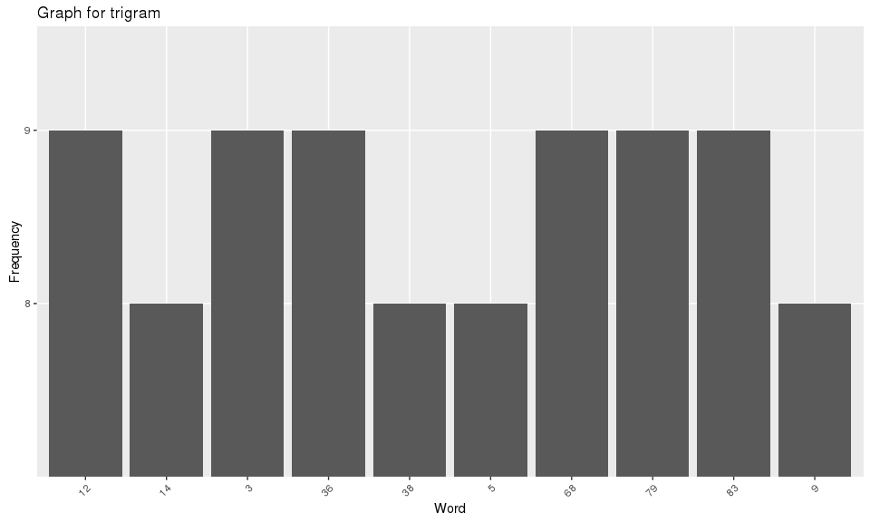

```r
llply(nG3, function(x) plotGraph(x, "trigram"))
```

## 5.2 Shiny App

**Under Construction !!!**

I simply created a shiny app… Kindly refer to http://beta.rstudioconnect.com…

# 6. Conclusion

From the text mining for the german dataset, we sampling the dataset to get the high frequency of occurence of words. Compare to previous version, from the report I also applied `tm`, `wordcloud`, `googleVis`, `rCharts` and `RWeka` packages etc to enhance and display a better data visualization on text mining.

By the way I’ve created a shiny app for displaying the ability to predict the next word based on the high frequency rate. The frequency rate would depict the best predictive model.

**Remarks** :

- Due to some technical errors on the *rpart* and *RWeka* packages, here I ommit the section by made a crossline.
- Due to I tried to some solutions to plot the output by codes `p1$print('inline', include_assets = F, cdn = FALSE)`, `p1$show('inline', include_assets = FALSE, cdn = FALSE)`, `p1`, `p1$show()`, `p1$print()` but no one works for me. Below are some references.
  1. [Display two rCharts NVD3 figures next to each other in rmarkdown](http://stackoverflow.com/questions/29029718/display-two-rcharts-nvd3-figures-next-to-each-other-in-rmarkdown)
  2. [Are rCharts and DT compatible in rmarkdown?](http://stackoverflow.com/questions/30212788/are-rcharts-and-dt-compatible-in-rmarkdown)
  3. [Rcharts nPlot() Percentages with discrete/multiBarChart](http://stackoverflow.com/questions/19716356/rcharts-nplot-percentages-with-discrete-multibarchart)

# 7. Appendices

- Section [6.1 Documenting File Creation]
- Section [6.2 Versions’ Log]

## 7.1 Documenting File Creation

It’s useful to record some information about how your file was created.

[1] “2016-04-28 10:50:22 EDT” setting value  
version R version 3.2.3 (2015-12-10) system x86_64, linux-gnu  
ui X11  
language (EN)  
collate en_US.UTF-8  
tz America/New_York  
date 2016-04-28  
sysname release “Linux” “3.10.0-229.20.1.el7.x86_64” version nodename “#1 SMP Tue Nov 3 19:10:07 UTC 2015” “scibrokes” machine login “x86_64” “unknown” user effective_user “ryoeng” “ryoeng”

## 7.2 Versions’ Log

- *Apr 22, 2016*: version 1.0.1
- *March 14, 2015*: [version: 1.0.0](http://rpubs.com/englianhu/MilestoneReport)

## 7.3 References

- [Auto Text Suggestion App](http://rpubs.com/plalithas/AutoTextMilestoneReport)
- [Text Prediction With R](http://rstudio-pubs-static.s3.amazonaws.com/39014_76f8487a8fb84ed7849e96846847c295.html)
- [*rCharts* Manual](http://rcharts.readthedocs.org/en/latest/intro/create.html)
- [Interactive Analysis of Systematic Investor](http://timelyportfolio.github.io/rCharts_nvd3_systematic/cluster_weights.html)